# Why you have sleep disorders

Whitney Zhu

2024-09-24

## Intro

Sleep disorders are a growing public health concern, impacting millions globally. Beyond lifestyle factors like screen time and physical activity, research is increasingly focusing on how occupation, gender, and other variables contribute to sleep quality. These factors can influence not only physical well-being but also mental health, leading to issues such as chronic fatigue and increased cardiovascular risks. This project delves into the complex relationships between sleep patterns and diverse influences, including work-related stress, gender disparities, and lifestyle choices, offering comprehensive insights into the causes and potential mitigations of sleep disorders.

In this study, we used the Sleep Health and Lifestyle dataset (UOM190346a 2023).

## Load the Sleep Health and Lifestyle Dataset

```r
sleep_data <- read_csv("~/Downloads/Sleep_health_and_lifestyle_dataset.csv")
head(sleep_data)
```

```
## # A tibble: 6 × 13
##   `Person ID` Gender   Age Occupation        `Sleep Duration` `Quality of Sleep`
##         <dbl> <chr>  <dbl> <chr>                        <dbl>              <dbl>
## 1           1 Male      27 Software Engineer              6.1                  6
## 2           2 Male      28 Doctor                         6.2                  6
## 3           3 Male      28 Doctor                         6.2                  6
## 4           4 Male      28 Sales Representa…              5.9                  4
## 5           5 Male      28 Sales Representa…              5.9                  4
## 6           6 Male      28 Software Engineer              5.9                  4
## # ℹ 7 more variables: `Physical Activity Level` <dbl>, `Stress Level` <dbl>,
## #   `BMI Category` <chr>, `Blood Pressure` <chr>, `Heart Rate` <dbl>,
## #   `Daily Steps` <dbl>, `Sleep Disorder` <chr>
```

*Data Features*

Person ID: An identifier for each individual.

Gender: The gender of the person (Male/Female).

Age: The age of the person in years.

Occupation: The occupation or profession of the person.

Sleep Duration (hours): The number of hours the person sleeps per day.

Quality of Sleep (scale: 1-10): A subjective rating of the quality of sleep, ranging from 1 to 10.

Physical Activity Level (minutes/day): The number of minutes the person engages in physical activity daily.

Stress Level (scale: 1-10): A subjective rating of the stress level experienced by the person, ranging from 1 to 10.

BMI Category: The BMI category of the person (e.g., Underweight, Normal, Overweight).

Blood Pressure (systolic/diastolic): The blood pressure measurement of the person, indicated as systolic pressure over diastolic pressure.

Heart Rate (bpm): The resting heart rate of the person in beats per minute.

Daily Steps: The number of steps the person takes per day.

Sleep Disorder: The presence or absence of a sleep disorder in the person (None, Insomnia, Sleep Apnea).

## Clear the Dataset

```r
summary(sleep_data)
```

```
##    Person ID         Gender               Age         Occupation
##  Min.   :  1.00   Length:374         Min.   :27.00   Length:374
##  1st Qu.: 94.25   Class :character   1st Qu.:35.25   Class :character
##  Median :187.50   Mode  :character   Median :43.00   Mode  :character
##  Mean   :187.50                      Mean   :42.18
##  3rd Qu.:280.75                      3rd Qu.:50.00
##  Max.   :374.00                      Max.   :59.00
##  Sleep Duration  Quality of Sleep Physical Activity Level  Stress Level
##  Min.   :5.800   Min.   :4.000    Min.   :30.00           Min.   :3.000
##  1st Qu.:6.400   1st Qu.:6.000    1st Qu.:45.00           1st Qu.:4.000
##  Median :7.200   Median :7.000    Median :60.00           Median :5.000
##  Mean   :7.132   Mean   :7.313    Mean   :59.17           Mean   :5.385
##  3rd Qu.:7.800   3rd Qu.:8.000    3rd Qu.:75.00           3rd Qu.:7.000
##  Max.   :8.500   Max.   :9.000    Max.   :90.00           Max.   :8.000
##  BMI Category       Blood Pressure       Heart Rate     Daily Steps
##  Length:374         Length:374         Min.   :65.00   Min.   : 3000
##  Class :character   Class :character   1st Qu.:68.00   1st Qu.: 5600
##  Mode  :character   Mode  :character   Median :70.00   Median : 7000
##                                        Mean   :70.17   Mean   : 6817
##                                        3rd Qu.:72.00   3rd Qu.: 8000
##                                        Max.   :86.00   Max.   :10000
##  Sleep Disorder
##  Length:374
##  Class :character
##  Mode  :character
##
##
##
```

```r
sleep_data <- sleep_data %>%
  filter(complete.cases(.))

colnames(sleep_data)
```

```
##  [1] "Person ID"               "Gender"
##  [3] "Age"                     "Occupation"
##  [5] "Sleep Duration"          "Quality of Sleep"
##  [7] "Physical Activity Level" "Stress Level"
##  [9] "BMI Category"            "Blood Pressure"
## [11] "Heart Rate"              "Daily Steps"
## [13] "Sleep Disorder"
```

```r
sleep_data <- sleep_data %>%
  rename(
    Person_ID = `Person ID`,
    Sleep_Duration = `Sleep Duration`,
    Quality_of_Sleep = `Quality of Sleep`,
    Physical_Activity_Level = `Physical Activity Level`,
    Stress_Level = `Stress Level`,
    BMI_Category = `BMI Category`,
    Blood_Pressure = `Blood Pressure`,
    Heart_Rate = `Heart Rate`,
    Daily_Steps = `Daily Steps`,
    Sleep_Disorder = `Sleep Disorder`
  )
```

## Data Visualization

### Distribution of persons have sleep disorder or not

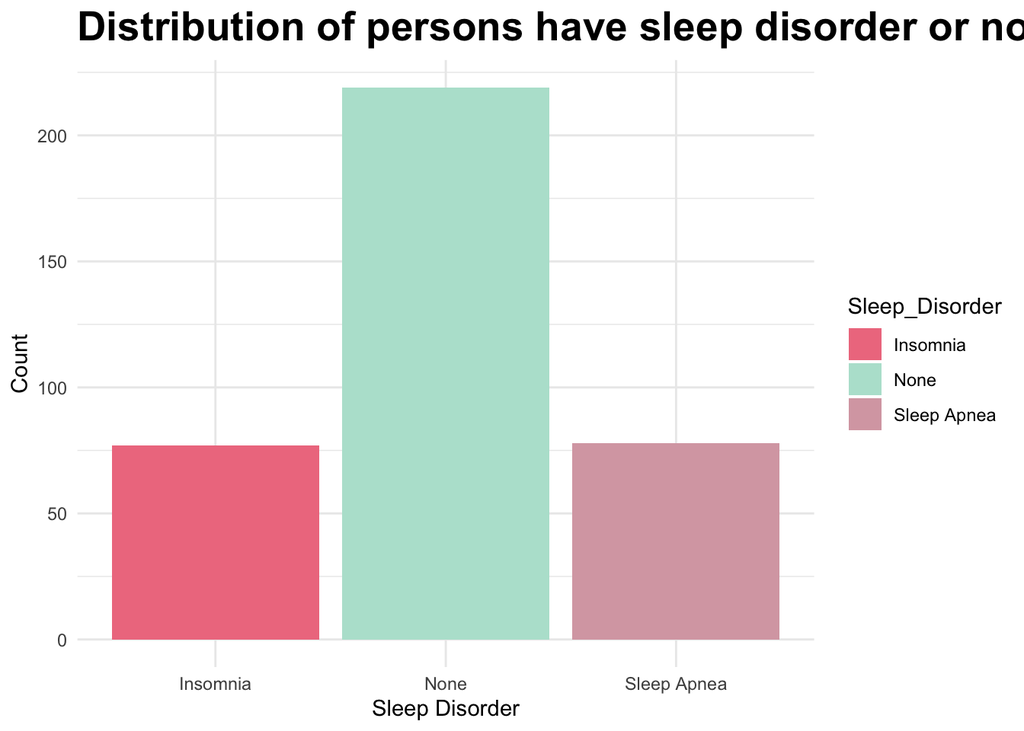

```r
ggplot(sleep_data, aes(x = Sleep_Disorder, fill = Sleep_Disorder)) +
  geom_bar(stat = "count", position = "dodge") +
  scale_fill_manual(values = c("#ef7c8e", "#b6e2d3", "#d8a7b1")) +
  labs(title = "Distribution of persons have sleep disorder or not",
       x = "Sleep Disorder", y = "Count") +
  theme_minimal() +
  theme(
    plot.title = element_text(size = 20, face = "bold"),
    axis.text.x = element_text(angle = 0, hjust = 0.5),
    plot.background = element_blank(),
    panel.background = element_blank(),
    legend.position = "right",
    legend.background = element_blank(),
    legend.key = element_blank()
  )
```

There is a significant difference in sleep disorder prevalence. A majority of the population reports no sleep disorders, while a considerable portion suffers from either insomnia or sleep apnea. These findings underscore the need for targeted interventions, particularly for individuals with diagnosed sleep disorders, as they represent a sizable group affected by sleep-related health issues.

### The effects of gender on Sleep

```r
gender_counts <- sleep_data %>%
  group_by(Sleep_Disorder, Gender) %>%
  summarise(count = n()) %>%
  arrange(Sleep_Disorder, desc(count))
print(gender_counts)
```

```
## # A tibble: 6 × 3
## # Groups:   Sleep_Disorder [3]
##   Sleep_Disorder Gender count
##   <chr>          <chr>  <int>
## 1 Insomnia       Male      41
## 2 Insomnia       Female    36
## 3 None           Male     137
## 4 None           Female    82
## 5 Sleep Apnea    Female    67
## 6 Sleep Apnea    Male      11
```

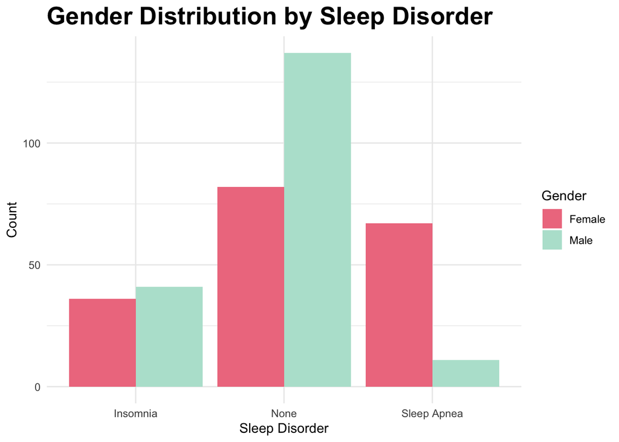

```r
ggplot(gender_counts, aes(x = Sleep_Disorder, y = count, fill = Gender)) +
  geom_bar(stat = "identity", position = "dodge") +
  scale_fill_manual(values = c("#ef7c8e", "#b6e2d3")) +
  labs(title = "Gender Distribution by Sleep Disorder",
       x = "Sleep Disorder",
       y = "Count",
       fill = "Gender") +
  theme_minimal() +
  theme(
    plot.title = element_text(size = 20, face = "bold"),
    axis.text.x = element_text(angle = 0, hjust = 0.5),
    plot.background = element_blank(),
    panel.background = element_blank(),
    legend.position = "right",
    legend.background = element_blank(),
    legend.key = element_blank()
  )
```

The bar chart illustrates the distribution of sleep disorders by gender. In the “None” category, males outnumber females significantly, indicating that more men report having no sleep disorders. For insomnia, there are slightly more males than females, but the difference is relatively small. However, in the case of sleep apnea, females are overwhelmingly more affected than males, as shown by the stark contrast in the bar heights. This suggests that sleep apnea is more prevalent among females in this dataset. Overall, the chart highlights distinct gender differences in the prevalence of specific sleep disorders.

### The effects of Age on Sleep

```r
age_sleep_summary <- sleep_data %>%
  group_by(Sleep_Disorder) %>%
  summarise(
    mean_age = mean(Age, na.rm = TRUE),
    median_age = median(Age, na.rm = TRUE),
    count = n()
  )

print(age_sleep_summary)
```

```
## # A tibble: 3 × 4
##   Sleep_Disorder mean_age median_age count
##   <chr>             <dbl>      <dbl> <int>
## 1 Insomnia           43.5         44    77
## 2 None               39.0         38   219
## 3 Sleep Apnea        49.7         50    78
```

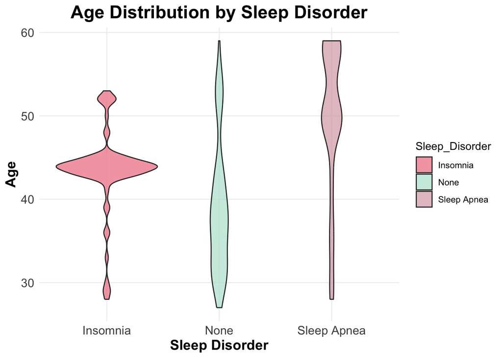

```r
ggplot(sleep_data, aes(x = Sleep_Disorder, y = Age, fill = Sleep_Disorder)) +
  geom_violin(alpha = 0.7) +
  scale_fill_manual(values = c("#ef7c8e", "#b6e2d3", "#d8a7b1")) +
  labs(title = "Age Distribution by Sleep Disorder",
       x = "Sleep Disorder",
       y = "Age") +
  theme_minimal() +
  theme(
    plot.title = element_text(size = 18, face = "bold", hjust = 0.5),
    axis.title = element_text(size = 14, face = "bold"),
    axis.text = element_text(size = 12),
    panel.grid.major = element_line(color = "#f0f0f0"),
    panel.grid.minor = element_blank()
  )
```

### The effects of Job on Sleep

```r
occupation_counts <- sleep_data %>%
  group_by(Sleep_Disorder, Occupation) %>%
  summarise(count = n()) %>%
  arrange(Sleep_Disorder, desc(count))
print(occupation_counts)
```

```
## # A tibble: 26 × 3
## # Groups:   Sleep_Disorder [3]
##    Sleep_Disorder Occupation        count
##    <chr>          <chr>             <int>
##  1 Insomnia       Salesperson          29
##  2 Insomnia       Teacher              27
##  3 Insomnia       Accountant            7
##  4 Insomnia       Engineer              5
##  5 Insomnia       Doctor                3
##  6 Insomnia       Nurse                 3
##  7 Insomnia       Lawyer                2
##  8 Insomnia       Software Engineer     1
##  9 None           Doctor               64
## 10 None           Engineer             57
## # ℹ 16 more rows
```

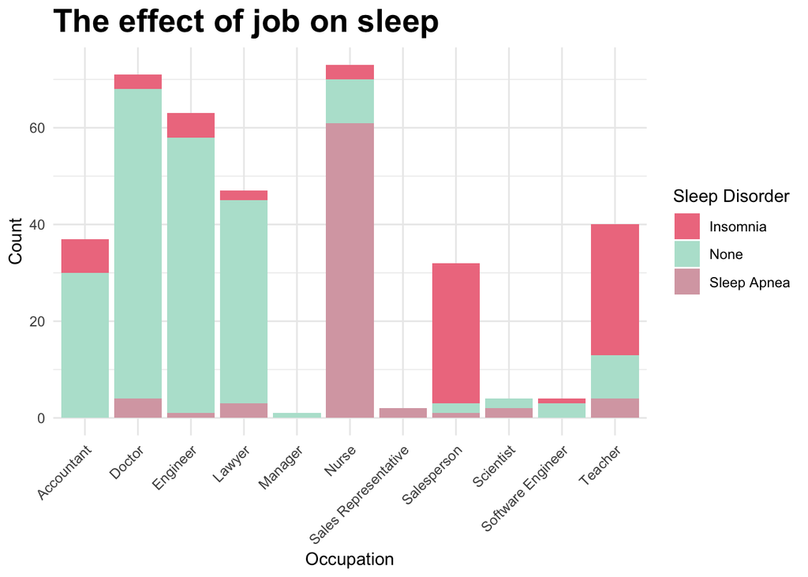

```r
ggplot(sleep_data, aes(x = Occupation, fill = Sleep_Disorder)) +
  geom_bar(position = "stack") +
  scale_fill_manual(values = c("#ef7c8e", "#b6e2d3", "#d8a7b1")) +
  labs(title = "The effect of job on sleep",
       x = "Occupation",
       y = "Count",
       fill = "Sleep Disorder") +
  theme_minimal() +
  theme(
    plot.title = element_text(size = 20, face = "bold"),
    axis.text.x = element_text(angle = 45, hjust = 1)
  )
```

The chart indicates a significant correlation between occupation and sleep disorders. Most doctors and engineers appear to be unaffected by sleep disorders, as indicated by the large proportion of individuals classified as “None.” However, nurses and sales representatives show a higher prevalence of sleep apnea, especially among nurses. Insomnia is more common among salespersons and teachers, suggesting that these professions may be associated with higher stress levels, potentially affecting sleep quality. Overall, the chart highlights how different job types may influence the likelihood of experiencing specific sleep disorders, likely due to varying work pressures and lifestyles.

### Relationship between Blood Pressure,Heart Rate and Sleep Disorder

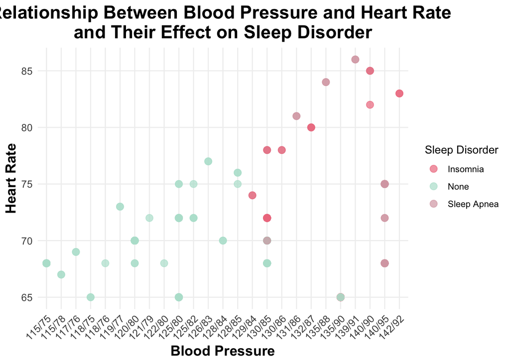

```r
ggplot(sleep_data, aes(x = Blood_Pressure, y = Heart_Rate, color = Sleep_Disorder)) +
  geom_point(size = 3, alpha = 0.7) +
  scale_color_manual(values = c("#ef7c8e", "#b6e2d3", "#d8a7b1")) +
  labs(title = "Relationship Between Blood Pressure and Heart Rate \nand Their Effect on Sleep Disorder",
       x = "Blood Pressure",
       y = "Heart Rate",
       color = "Sleep Disorder") +
  theme_minimal() +
  theme(
    plot.title = element_text(size = 18, face = "bold", hjust = 0.5),
    axis.title = element_text(size = 14, face = "bold"),
    axis.text = element_text(size = 10),
    axis.text.x = element_text(angle = 45, hjust = 1),
    panel.grid.major = element_line(color = "#f0f0f0"),
    panel.grid.minor = element_blank()
  )
```

## Reflection

*Aims:* I wanted to explore the relationship between sleep disorders and factors like occupation, lifestyle, and health, and represent the findings using beautiful, clear visualizations.

*What went well:* I managed to create some nice visualizations that show trends, like how different types of sleep disorders are distributed across various groups.

*What didn’t go well:* The biggest issue was realizing, midway through the analysis, that the data set isn’t strong enough to fully support the deeper relationships I hoped to explore. I also struggled to find external data to back up my findings, which made me question whether I should continue with the same data or switch to a more comprehensive source.

*Next steps:* In the future, I plan to explore the relationship between sleep disorders and more factors, and experiment with different ways of visualizing these relationships. I also want to improve the way I present the findings, making the story behind the data more vivid and relatable instead of just explaining the charts.

UOM190346a. 2023. “Sleep Health and Lifestyle Dataset.” https://www.kaggle.com/datasets/uom190346a/sleep-health-and-lifestyle-dataset/data.